# Regression and model validation

```r
date()
```

```
## [1] "Fri Nov 11 20:28:11 2022"
```

```r
# READING IN THE ORIGINAL DATASET

# Read the data into memory
learning2014 <- read.table("http://www.helsinki.fi/~kvehkala/JYTmooc/JYTOPKYS3-data.txt", sep="\t", header=TRUE)

# Look at the dimensions and structure of the data
dim(learning2014)
```

```
## [1] 183  60
```

```r
# str(learning2014)
```

The dataset used in this exercise is based on an international survey of students’ approaches to learning in 2013-2015. Measures in the parts A, B and C come from the ASSIST (Approaches and Study Skills Inventory for Students) questionnaire and the part D is based on the SATS (Survey of Attitudes Toward Statistics) questionnaire. Some background and other variables have been omitted, but all 183 responses are included. So all in all, there are 60 variables and 183 observations included. All variables except the one on gender are integers. No values are missing.

```r
# CREATING THE ANALYSIS DATASET

# Access the dplyr library
library(dplyr)
# Create an analysis dataset
deep_questions <- c("D03", "D11", "D19", "D27", "D07", "D14", "D22", "D30","D06",  "D15", "D23", "D31")
surface_questions <- c("SU02","SU10","SU18","SU26", "SU05","SU13","SU21","SU29","SU08","SU16","SU24","SU32")
strategic_questions <- c("ST01","ST09","ST17","ST25","ST04","ST12","ST20","ST28")

learn2014an <- learning2014 %>% select(gender, Age, Points)
learn2014an$deep <- rowMeans(learning2014[, deep_questions])
learn2014an$surf <- rowMeans(learning2014[, surface_questions])
learn2014an$stra <- rowMeans(learning2014[, strategic_questions])

# create the column 'attitude' by scaling the column "Attitude"
learn2014an$attitude <- learning2014$Attitude / 10

# print out the column names of the data
colnames(learn2014an)
```

```
## [1] "gender"   "Age"      "Points"   "deep"     "surf"     "stra"     "attitude"
```

```r
# change the names of certain columns
colnames(learn2014an)[2] <- "age"
colnames(learn2014an)[3] <- "points"

# select rows where points is greater than zero
learn2014an <- filter(learn2014an, points > 0)

# Look at the dimensions and structure of the analysis data
# dim(learn2014an)
str(learn2014an)
```

```
## 'data.frame':    166 obs. of  7 variables:
##  $ gender  : chr  "F" "M" "F" "M" ...
##  $ age     : int  53 55 49 53 49 38 50 37 37 42 ...
##  $ points  : int  25 12 24 10 22 21 21 31 24 26 ...
##  $ deep    : num  3.58 2.92 3.5 3.5 3.67 ...
##  $ surf    : num  2.58 3.17 2.25 2.25 2.83 ...
##  $ stra    : num  3.38 2.75 3.62 3.12 3.62 ...
##  $ attitude: num  3.7 3.1 2.5 3.5 3.7 3.8 3.5 2.9 3.8 2.1 ...
```

In the analysis dataset, variables on gender, age and points are unmodified but the variable on attitude is modified by dividing the original one by 10, and new variables deep, surf and stra are formed by averaging the respective part B variables. Attitude measures the global attitude towards statistics. Deep is a measure on how inclined the participant is towards deep learning, surf is a measure on how superficially the participant approaches his or her studying, and stra is a measure on how organized the participant’s manner is in studying. Points are the points obtained in an exam in a course on Introduction to Social Statistics.

The value 0 in points actually means that the participant did not participate in the exam (n = 17, 9%). These participants are excluded from the analysis dataset. Thus the dataset consists of 7 variables and 166 observations.

```r
# SAVING THE ANALYSIS DATASET AND CHECKING THAT READING ANEW WORKS

# Set the working directory
setwd("C:/Users/yona2/Desktop/FT/IODS2022/RStudio/IODS-project/data")

# Access the tidyverse library
library(tidyverse)
# Save the analysis dataset
write.csv(learn2014an,"learn2014an.csv", row.names = FALSE)

# Checking that reading of the saved file works
# learn2014an2 <- read.table("learn2014an.csv", sep=",", header=TRUE)
# str(learn2014an2)
# head(learn2014an2)
```

Saving and reading the saved file work as expected.

```r
# EXPLORING THE ANALYSIS DATA

# Access the GGally, ggplot2 and cowplot libraries
library(GGally)
library(ggplot2)

# Get summary values
learn2014an %>% group_by(gender) %>% summarise(count= n())
```

```
## # A tibble: 2 × 2
##   gender count
##   <chr>  <int>
## 1 F        110
## 2 M         56
```

```r
summarise_at(learn2014an, vars(attitude:points), tibble::lst(mean, sd))
```

```
##   attitude_mean stra_mean surf_mean deep_mean points_mean attitude_sd   stra_sd
## 1      3.142771  3.121235  2.787149  3.679719    22.71687   0.7299079 0.7718318
##     surf_sd   deep_sd points_sd
## 1 0.5288405 0.5541369  5.894884
```

```r
learn2014an %>% group_by(gender) %>% summarise_at(vars(age), tibble::lst(mean, sd, min, median, max))
```

```
## # A tibble: 2 × 6
##   gender  mean    sd   min median   max
##   <chr>  <dbl> <dbl> <int>  <dbl> <int>
## 1 F       24.9  7.36    17     22    53
## 2 M       26.8  8.43    19     24    55
```

```r
learn2014an %>% group_by(gender) %>% summarise_at(vars(attitude), tibble::lst(mean, sd, min, median, max))
```

```
## # A tibble: 2 × 6
##   gender  mean    sd   min median   max
##   <chr>  <dbl> <dbl> <dbl>  <dbl> <dbl>
## 1 F       2.99 0.725   1.4   2.95   5
## 2 M       3.44 0.646   1.7   3.4    4.8
```

```r
learn2014an %>% group_by(gender) %>% summarise_at(vars(deep), tibble::lst(mean, sd, min, median, max))
```

```
## # A tibble: 2 × 6
##   gender  mean    sd   min median   max
##   <chr>  <dbl> <dbl> <dbl>  <dbl> <dbl>
## 1 F       3.66 0.535  1.58   3.67  4.75
## 2 M       3.72 0.592  2.08   3.79  4.92
```

```r
learn2014an %>% group_by(gender) %>% summarise_at(vars(surf), tibble::lst(mean, sd, min, median, max))
```

```
## # A tibble: 2 × 6
##   gender  mean    sd   min median   max
##   <chr>  <dbl> <dbl> <dbl>  <dbl> <dbl>
## 1 F       2.83 0.458  1.83   2.83  4
## 2 M       2.70 0.642  1.58   2.62  4.33
```

```r
learn2014an %>% group_by(gender) %>% summarise_at(vars(stra), tibble::lst(mean, sd, min, median, max))
```

```
## # A tibble: 2 × 6
##   gender  mean    sd   min median   max
##   <chr>  <dbl> <dbl> <dbl>  <dbl> <dbl>
## 1 F       3.20 0.748  1.38   3.25   5
## 2 M       2.96 0.801  1.25   3      4.5
```

```r
learn2014an %>% group_by(gender) %>% summarise_at(vars(points), tibble::lst(mean, sd, min, median, max))
```

```
## # A tibble: 2 × 6
##   gender  mean    sd   min median   max
##   <chr>  <dbl> <dbl> <int>  <dbl> <int>
## 1 F       22.3  5.83     7   23      33
## 2 M       23.5  6.01     9   23.5    33
```

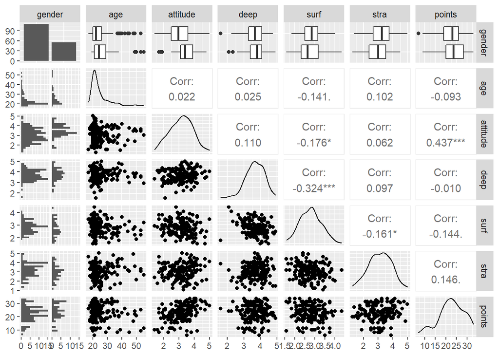

```r
# Create and draw a more advanced plot matrix with ggpairs()
p <- ggpairs(learn2014an[, c(1, 2, 7, 4, 5, 6, 3)], mapping = aes(), lower = list(combo = wrap("facethist", bins = 20)), progress = FALSE)
p
```

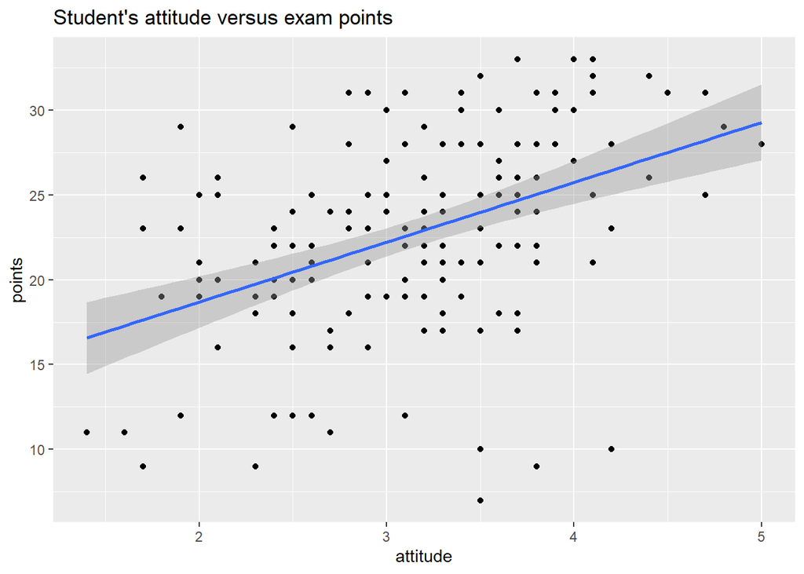

```r
# Initialize plot with data and aesthetic mapping
p1 <- ggplot(learn2014an, aes(x = attitude, y = points))

# Define the visualization type (points) + add a regression line
# + add a main title and draw the plot
p2 <- p1 + geom_point() + geom_smooth(method = "lm") + ggtitle("Student's attitude versus exam points")
p2
```

Out of 166 participants, 56 (34%) are men and 110 (66%) women. The age ranges from 17 to 55 years, the average age (sd) being 26.8 (8.4) years for men and 24.9 (7.4) years for women. Mean scores (sd) are 3.1 (0.7) for attitude, 3.7 (0.6) for deep, 2.8 (0.5) for surf, 3.1 (0.8) for stra and 22.7 (5.9) for points. The distribution of age is skewed to the right, otherwise the distributions are reasonably symmetrical and do not noteworthy differ between gender.

Attitude is significantly correlated with points (rho = 0.44), which association can be seen nicely in the respective plot. On the other hand, surf is slightly negatively (rho -0.14) and stra slightly positively (rho = 0.15) correlated with points, as expected. There is statistically significant negative correlation between surf and attitude (rho = -0.18), deep (rho = -0.32) and stra (rho = -0.16), as expected. Otherwise the associations are unremarkable.

```r
# BUILDING A MULTIPLE REGRESSION MODEL

# Fit a linear model
my_model1 <- lm(points ~ age, data = learn2014an)
my_model2 <- lm(points ~ gender, data = learn2014an)
my_model3 <- lm(points ~ attitude, data = learn2014an)
my_model4 <- lm(points ~ deep, data = learn2014an)
my_model5 <- lm(points ~ surf, data = learn2014an)
my_model6 <- lm(points ~ stra, data = learn2014an)

my_model31 <- lm(points ~ attitude + stra + surf, data = learn2014an)
my_model32 <- lm(points ~ attitude + age + gender, data = learn2014an)

# Print out a summary of the models
summary(my_model1)
```

```
##
## Call:
## lm(formula = points ~ age, data = learn2014an)
##
## Residuals:
##      Min       1Q   Median       3Q      Max
## -16.0360  -3.7531   0.0958   4.6762  10.8128
##
## Coefficients:
##             Estimate Std. Error t value Pr(>|t|)
## (Intercept) 24.52150    1.57339  15.585   <2e-16 ***
## age         -0.07074    0.05901  -1.199    0.232
## ---
## Signif. codes:  0 '***' 0.001 '**' 0.01 '*' 0.05 '.' 0.1 ' ' 1
##
## Residual standard error: 5.887 on 164 degrees of freedom
## Multiple R-squared:  0.008684,   Adjusted R-squared:  0.00264
## F-statistic: 1.437 on 1 and 164 DF,  p-value: 0.2324
```

```r
summary(my_model2)
```

```
##
## Call:
## lm(formula = points ~ gender, data = learn2014an)
##
## Residuals:
##      Min       1Q   Median       3Q      Max
## -15.3273  -3.3273   0.5179   4.5179  10.6727
##
## Coefficients:
##             Estimate Std. Error t value Pr(>|t|)
## (Intercept)  22.3273     0.5613  39.776   <2e-16 ***
## genderM       1.1549     0.9664   1.195    0.234
## ---
## Signif. codes:  0 '***' 0.001 '**' 0.01 '*' 0.05 '.' 0.1 ' ' 1
##
## Residual standard error: 5.887 on 164 degrees of freedom
## Multiple R-squared:  0.008632,   Adjusted R-squared:  0.002587
## F-statistic: 1.428 on 1 and 164 DF,  p-value: 0.2338
```

```r
summary(my_model3)
```

```
##
## Call:
## lm(formula = points ~ attitude, data = learn2014an)
##
## Residuals:
##      Min       1Q   Median       3Q      Max
## -16.9763  -3.2119   0.4339   4.1534  10.6645
##
## Coefficients:
##             Estimate Std. Error t value Pr(>|t|)
## (Intercept)  11.6372     1.8303   6.358 1.95e-09 ***
## attitude      3.5255     0.5674   6.214 4.12e-09 ***
## ---
## Signif. codes:  0 '***' 0.001 '**' 0.01 '*' 0.05 '.' 0.1 ' ' 1
##
## Residual standard error: 5.32 on 164 degrees of freedom
## Multiple R-squared:  0.1906, Adjusted R-squared:  0.1856
## F-statistic: 38.61 on 1 and 164 DF,  p-value: 4.119e-09
```

```r
summary(my_model4)
```

```
##
## Call:
## lm(formula = points ~ deep, data = learn2014an)
##
## Residuals:
##      Min       1Q   Median       3Q      Max
## -15.6913  -3.6935   0.2862   4.9957  10.3537
##
## Coefficients:
##             Estimate Std. Error t value Pr(>|t|)
## (Intercept)  23.1141     3.0908   7.478 4.31e-12 ***
## deep         -0.1080     0.8306  -0.130    0.897
## ---
## Signif. codes:  0 '***' 0.001 '**' 0.01 '*' 0.05 '.' 0.1 ' ' 1
##
## Residual standard error: 5.913 on 164 degrees of freedom
## Multiple R-squared:  0.000103,   Adjusted R-squared:  -0.005994
## F-statistic: 0.01689 on 1 and 164 DF,  p-value: 0.8967
```

```r
summary(my_model5)
```

```
##
## Call:
## lm(formula = points ~ surf, data = learn2014an)
##
## Residuals:
##      Min       1Q   Median       3Q      Max
## -14.6539  -3.3744   0.3574   4.4734  10.2234
##
## Coefficients:
##             Estimate Std. Error t value Pr(>|t|)
## (Intercept)  27.2017     2.4432  11.134   <2e-16 ***
## surf         -1.6091     0.8613  -1.868   0.0635 .
## ---
## Signif. codes:  0 '***' 0.001 '**' 0.01 '*' 0.05 '.' 0.1 ' ' 1
##
## Residual standard error: 5.851 on 164 degrees of freedom
## Multiple R-squared:  0.02084,    Adjusted R-squared:  0.01487
## F-statistic:  3.49 on 1 and 164 DF,  p-value: 0.06351
```

```r
summary(my_model6)
```

```
##
## Call:
## lm(formula = points ~ stra, data = learn2014an)
##
## Residuals:
##      Min       1Q   Median       3Q      Max
## -16.5581  -3.8198   0.1042   4.3024  10.1394
##
## Coefficients:
##             Estimate Std. Error t value Pr(>|t|)
## (Intercept)   19.233      1.897  10.141   <2e-16 ***
## stra           1.116      0.590   1.892   0.0603 .
## ---
## Signif. codes:  0 '***' 0.001 '**' 0.01 '*' 0.05 '.' 0.1 ' ' 1
##
## Residual standard error: 5.849 on 164 degrees of freedom
## Multiple R-squared:  0.02135,    Adjusted R-squared:  0.01538
## F-statistic: 3.578 on 1 and 164 DF,  p-value: 0.06031
```

```r
summary(my_model31)
```

```
##
## Call:
## lm(formula = points ~ attitude + stra + surf, data = learn2014an)
##
## Residuals:
##      Min       1Q   Median       3Q      Max
## -17.1550  -3.4346   0.5156   3.6401  10.8952
##
## Coefficients:
##             Estimate Std. Error t value Pr(>|t|)
## (Intercept)  11.0171     3.6837   2.991  0.00322 **
## attitude      3.3952     0.5741   5.913 1.93e-08 ***
## stra          0.8531     0.5416   1.575  0.11716
## surf         -0.5861     0.8014  -0.731  0.46563
## ---
## Signif. codes:  0 '***' 0.001 '**' 0.01 '*' 0.05 '.' 0.1 ' ' 1
##
## Residual standard error: 5.296 on 162 degrees of freedom
## Multiple R-squared:  0.2074, Adjusted R-squared:  0.1927
## F-statistic: 14.13 on 3 and 162 DF,  p-value: 3.156e-08
```

```r
summary(my_model32)
```

```
##
## Call:
## lm(formula = points ~ attitude + age + gender, data = learn2014an)
##
## Residuals:
##      Min       1Q   Median       3Q      Max
## -17.4590  -3.3221   0.2186   4.0247  10.4632
##
## Coefficients:
##             Estimate Std. Error t value Pr(>|t|)
## (Intercept) 13.42910    2.29043   5.863 2.48e-08 ***
## attitude     3.60657    0.59322   6.080 8.34e-09 ***
## age         -0.07586    0.05367  -1.414    0.159
## genderM     -0.33054    0.91934  -0.360    0.720
## ---
## Signif. codes:  0 '***' 0.001 '**' 0.01 '*' 0.05 '.' 0.1 ' ' 1
##
## Residual standard error: 5.315 on 162 degrees of freedom
## Multiple R-squared:  0.2018, Adjusted R-squared:  0.187
## F-statistic: 13.65 on 3 and 162 DF,  p-value: 5.536e-08
```

```r
summary(my_model3)
```

```
##
## Call:
## lm(formula = points ~ attitude, data = learn2014an)
##
## Residuals:
##      Min       1Q   Median       3Q      Max
## -16.9763  -3.2119   0.4339   4.1534  10.6645
##
## Coefficients:
##             Estimate Std. Error t value Pr(>|t|)
## (Intercept)  11.6372     1.8303   6.358 1.95e-09 ***
## attitude      3.5255     0.5674   6.214 4.12e-09 ***
## ---
## Signif. codes:  0 '***' 0.001 '**' 0.01 '*' 0.05 '.' 0.1 ' ' 1
##
## Residual standard error: 5.32 on 164 degrees of freedom
## Multiple R-squared:  0.1906, Adjusted R-squared:  0.1856
## F-statistic: 38.61 on 1 and 164 DF,  p-value: 4.119e-09
```

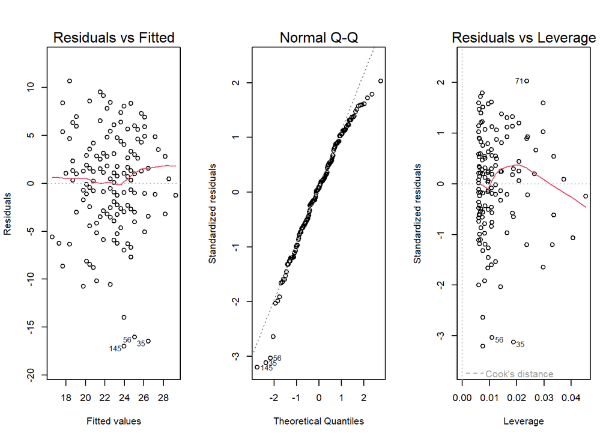

```r
# Draw diagnostic plots using the plot() function, choosing the plots 1, 2 and 5
par(mfrow = c(1,3))
plot(my_model3, which = c(1, 2, 5))
```

In univariate regression models, only attitude has a statistically significant association with points (p = 4.12e-09). Surf and stra are marginally associated with points (p = 0.06 for both).

Attitude, surf and stra are selected as explanatory variables for a multiple regression model. In the model, attitude preserves its statistical significance while surf and stra do not add much to it. The overall fitness of the model do not improve: there is practically no change in multiple R-squared (0.21 in the multiple regression and 0.19 in the univariate model) and the overall p actually worsens (3.16e-08 in the multiple regression and 4.12e-09 in the univariate model). Likewise, adding demographic factors age and gender to the model do not improve it.

Therefore, for the final model, only attitude is selected as an explanatory variable. An increase of one unit in attitude is associated with an increase of 3.5 points in the exam results. Based on the multiple R-squared statistics, scores in attitude explained 19 % of the variation in points. Even though this “explanatory power” is rather small, the model was statistically highly significant (F = 38.6 with 1 and 164 df, p = 4.12e-09). This kind of result is rather typical for human behavioral data.

In a linear regression model, the association between the dependant and explanatory variable are assumed to be linear and monotonously increasing or decreasing. The included variables should be normally distributed and the explanatory variables uncorrelated with each other. The diagnostic plots did not show any noteworthy deviance; there were a couple of outliers that did not seem to distort the association between attitude and points. The distributions of both attitude and points were reasonably symmetrical and close enough to normal. In the scatter plot on points by attitude, the association seemed clearly monotonously increasing.